EdMOOC-Survival: Home - Typical Curves - Analysis

# Typical Survival Curves

This page shows the shapes of various survival-related curves, using some well-known parametric equations and parameter values comparable to those found in the data. Its purpose is to aid interpretation of the observed MOOC last-access-time data by showing theoretical curves following simple parametric models.

In all that follows, time is measured in days starting at time=0 and “survival” is understood to be the fraction of learners that are still engaged with the course at a given point in time.

## Parametric Equations

These describe idealised theoretical survival/loss scenarios with a small number of parameters that may be adjusted such that the equation approximately matches observed data, i.e. “fitting”.

### Exponential

Exponential decay occurs when a fixed proportion of a population is lost in equal time intervals. An exponential form for MOOC last access data would suggest that essentially-random life events may explain the observation. This is the simplest explanation and if the quality of fit to real data is good, we should adopt it.

The equation for the fraction surviving, \( S(t) \) to time \( t \) is: \[ S(t)=e^{-\lambda t} \]

There is a single parameter, \( \lambda \), which may be fitted to observed data to reduce the difference between the observed and modelled values of S. The half-life, the time interval for half of the population to be lost, is given by \( ln(2)/\lambda \).

### Weibull

A second parameter, \( \gamma \), may be added to create the (2-parameter) Weibull survival function: \[ S(t)=e^{-\lambda t^\gamma} \]

This means that the proportion of the population that is lost in equal intervals of time changes with time. Fitting to observed data that indicates a value of \( \gamma \) significantly different from 1, when the equation reduces to the exponential form, would show that students are more or less likely to discontinue access early in the course relative to the later stages. Values higher than 1 indicate an increasing drop-out rate and values less than 1 indicate a decreasing drop-out rate.

*Note that other parameterisations of the same mathematical form are used, and that there are different approaches between R packages and core, but the above approach is used for all quoted parameter values. An alternative forumalation uses \( (1/\eta)^\gamma \) in place of \( \lambda \). This parameterisation has the advantage that \( \eta \) is the time when 36.8% of the population will remain, irrespective of the value of \( \gamma \). See Therneau and Grambsch (2000).*

### Log-Logistic

This two-parameter function is of interest because it can model situations where the rate of loss may increase and decrease. Such a situation matches an intuition that the rate of loss of learners may first increase from its initial value, for example once the easy/introductory material has been covered, and later decrease, for example when the segment of the population that remains is adequately equipped to deal with the material.

\[ S(t)=[{1+({\rho t})^\gamma}]^{-1} \]

This curve has the property that \( S(t) \) will have fallen to one half when \( t=1/\rho \), irrespective of the value of the shape parameter, \( \gamma \). Values of \( \gamma \) greater than one give a rates of loss that both increase and decrease at different times, whereas values less than one give a progressively-decreasing dropout rate, although differently-shaped to the Weibull.

As for Weibull, readers should be cautious since alternative parameter definitions are found in the literature that are not used here, for example:

\[ S(t)=[{1+({t\over\alpha})^\beta}]^{-1} \]

## Survival Curves

The difference between the exponential and Weibull survival functions may be compared by plotting \( S(t) \) against time with the same value of \( \lambda \) and values of the Weibull \( \gamma \) both above and below 1, when the Weibull reduces to the exponential.

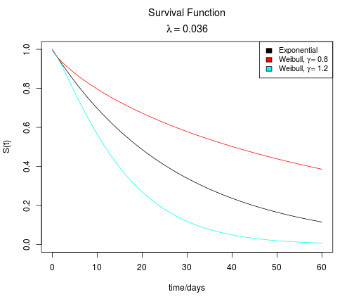

With the same value of \( \lambda \), the curves cross at \( t=1 \) day. This comprises a family of curves from a mathematical perspective but for interpreting MOOC survival data, it is more important to see how the Weibull \( \gamma \) affects the shape if the half-life is constant, i.e. a family where the crossing point is chosen to be the point where half of the population has been lost. In the following, the values of \( \gamma \) have been chosen and \( \lambda \) for the Weibull curves is varied to adjust the crossing-point.

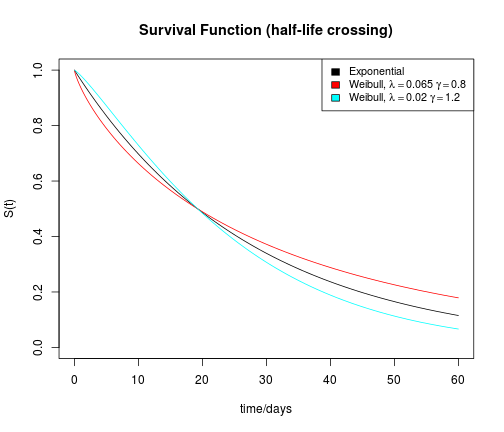

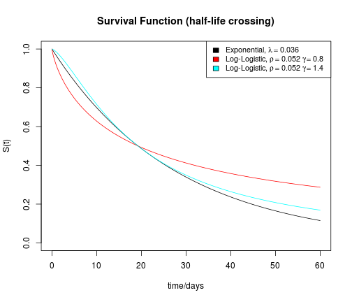

## Hazard Function Curves

These show what fraction of the population that survived until time=t but is lost time=t+1. The values of \( H(t) \) are more positive when the rate of loss is higher (i.e. the change between time t and t+1 is \( -H(t) \)) They make the differences between the shapes of the survival curves more clear.

The first plot corresponds to the first plot above, where \( \lambda \) is constant for the exponential and two Weibull function curves.

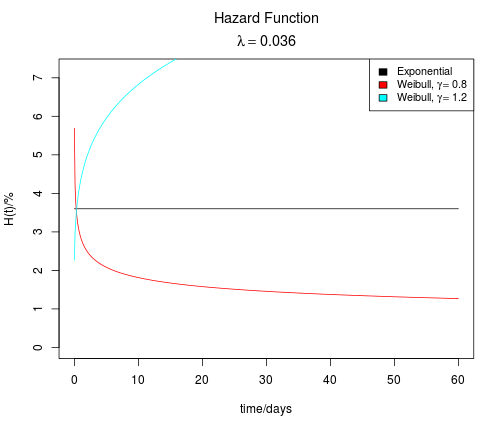

With the half-life crossing parameter values, note that the point where the \( H(t) \) for the Weibull curves crosses the exponential are very much earlier than the half-life, when \( S(t) \) cross, and not at the same value of t.

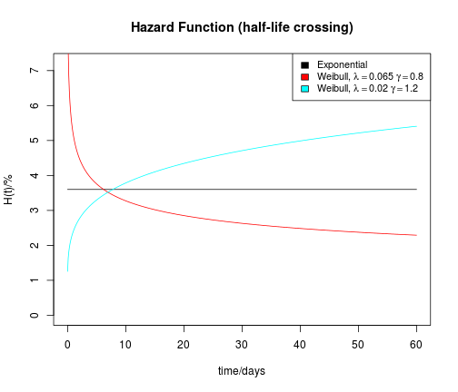

For the Log-Logistic curves with parameters as for the survival curves above, the changing rate with time, for the \( \gamma=1.4 \) case, is well illustrated.

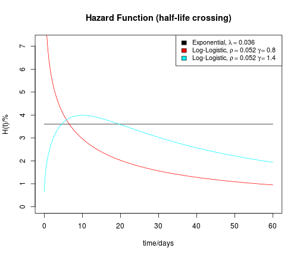

## References

R Core Team (2013). R: A language and environment for statistical computing. R Foundation for Statistical Computing, Vienna, Austria. URL http://www.R-project.org/.

Terry M. Therneau and Patricia M. Grambsch (2000). *Modeling Survival Data: Extending the Cox Model*. Springer, New York. ISBN 0-387-98784-3.

## About…

The content - source code and outputs - in EdMOOC-Survival were created by Adam Cooper, Cetis, University of Bolton, 2014. The work was undertaken for The University of Edinburgh DEI as part of their MOOC initiative. More information and data analysis is online at http://moocs.is.ed.ac.uk. Source code for EdMOOC-Survival is in GitHub at https://github.com/arc12/EdMOOC-Survival.

[Creative Commons Attribution-NonCommercial 4.0 International License](http://creativecommons.org/licenses/by-nc/4.0/)